# Wordcloud_Twitter#futurebass

b10401038

2018年10月10日

Future bass is an electronic dance music genre

## Import needed libraries

```r
rm(list=ls(all.names=TRUE))
library(twitteR)
library(tm)
```

```r
library(SnowballC)
library(wordcloud)
library(RColorBrewer)
```

## Setting up the API connection

Code hide for privacy and security.Example code below:

consumerKey <- “” consumerSecret <- “” accessToken <- “” accessSecret <- “” options(httr_oauth_cache=T) setup_twitter_oauth(consumerKey, consumerSecret, accessToken, accessSecret)

## Tweets extraction

To extract tweets based on #futurebass

```r
fub <- searchTwitter('#futurebass', n=10000)

#get text from tweets
fub_txt <- sapply(fub, function(x) x$getText())

#create a corpus
fub_doc <- Corpus(VectorSource(fub_txt))
```

## Clean the text data

```r
#to lower
fub_doc <- tm_map(fub_doc, content_transformer(tolower))

#remove anything other than English letters
removeNumPunct <- function(x)gsub("[^[:alpha:][:space:]]*", "", x)
fub_doc <- tm_map(fub_doc, content_transformer(removeNumPunct))

#remove URL
removeURL <- function(x) gsub("http[^[:space:]]*", "", x)
fub_doc <- tm_map(fub_doc, content_transformer(removeURL))

#remove emojis
fub_doc <- tm_map(fub_doc, content_transformer(gsub), pattern="\\W", replace=" ")

#remove punctuation, numbers, space, and stopwords
fub_doc <- tm_map(fub_doc, removePunctuation)
fub_doc <- tm_map(fub_doc, removeNumbers)
fub_doc <- tm_map(fub_doc, stripWhitespace)
fub_doc <- tm_map(fub_doc, removeWords, stopwords("en"))
```

## Wordcloud

```r
#term document matrix
fuba <- TermDocumentMatrix(fub_doc)
b <- as.matrix(fuba)
u <- sort(rowSums(b), decreasing = T)
f <- data.frame(word = names(u), freq=u)
head(f,10)
```

```
##                  word freq
## futurebass futurebass  481
## music           music  306
## edm               edm  294
## new               new  186
## now               now  170
## check           check  164
## like             like  126
## trap             trap  118
## remix           remix  113
## cage             cage  101
```

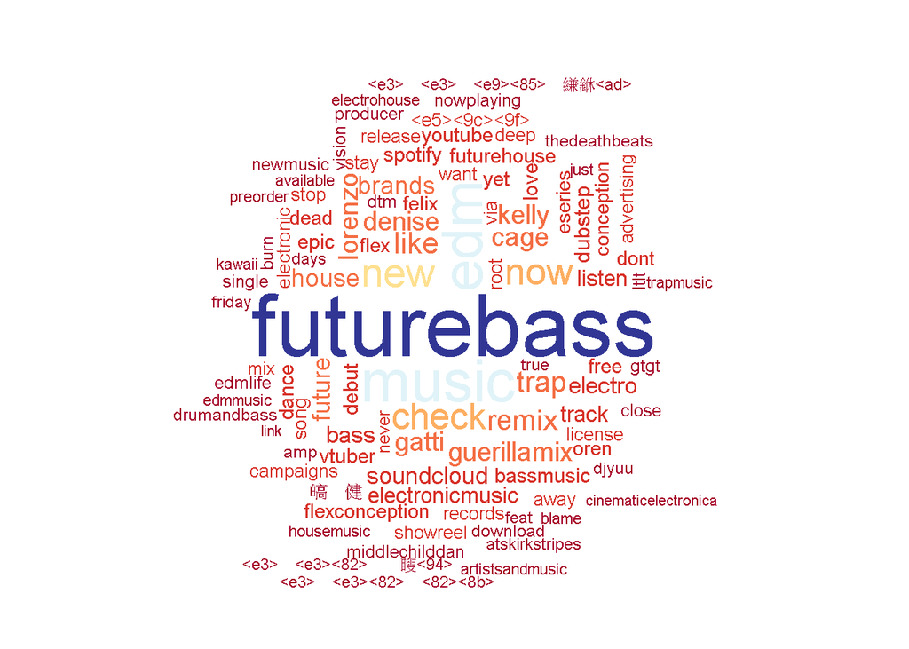

```r
#wordcloud
wordcloud(words = f$word, freq = f$freq, min.freq = 1, max.words =100,
          random.order = F, colors = brewer.pal(11,"RdYlBu"))
```

As you can see in wordcloud that the most freq word is **futurebass** which totally make sense. Furthermore,words like **edm**, **trap**, **house**, **dubstep** are music genres associated with futurebass, due to those twitter users often put many simmilar hashtags in their content toghter in order to get more views from different hashtag followers, or maybe their music really got these elements inside and they just want to identify their music .

Interestingly,there are words like **lorenzo**, **guerillamix**, **kelly**, **gatti**, **denise**, **cage** that I cant barely understand when the plot came out at the first time. After diging on twitter,I realized it was a new debut ep : *Lorenzo Gatti & Denise Kelly’s single ‘Like That’ from The Cage - EP* have out now, and guerillamix which is their music brand company had been posting a lots of text on twitter recently.